# Practical Machine Learning Course Project

Carolyn

Sunday, September 27, 2015

Download data. To be consistant, making all blank fields NA.

```r
download.file("https://d396qusza40orc.cloudfront.net/predmachlearn/pml-training.csv", "pml-training")
pmlTraining<-read.csv("pml-training")
pmlTraining[pmlTraining==""] <- NA
```

Create training and testing sets. For reproducibility, we set seed to 1.

```r
library(caret)
set.seed(1)
inTrain <- createDataPartition(y=pmlTraining$classe,
                              p=0.7, list=FALSE)
training <- pmlTraining[inTrain,]
testing <- pmlTraining[-inTrain,]
dim(training); dim(testing)
```

```
## [1] 13737   160
```

```
## [1] 5885  160
```

Let’s do some exploratory analysis and take a look at the columns.

```r
colnames(pmlTraining)
```

```
##   [1] "X"                        "user_name"
##   [3] "raw_timestamp_part_1"     "raw_timestamp_part_2"
##   [5] "cvtd_timestamp"           "new_window"
##   [7] "num_window"               "roll_belt"
##   [9] "pitch_belt"               "yaw_belt"
##  [11] "total_accel_belt"         "kurtosis_roll_belt"
##  [13] "kurtosis_picth_belt"      "kurtosis_yaw_belt"
##  [15] "skewness_roll_belt"       "skewness_roll_belt.1"
##  [17] "skewness_yaw_belt"        "max_roll_belt"
##  [19] "max_picth_belt"           "max_yaw_belt"
##  [21] "min_roll_belt"            "min_pitch_belt"
##  [23] "min_yaw_belt"             "amplitude_roll_belt"
##  [25] "amplitude_pitch_belt"     "amplitude_yaw_belt"
##  [27] "var_total_accel_belt"     "avg_roll_belt"
##  [29] "stddev_roll_belt"         "var_roll_belt"
```

[output cut: 65 more lines]

We notice that the first several columns are not useful in prediction, let’s delete them.

```r
training<-training[,8:160]
testing<-testing[,8:160]
```

Also notice there are many missing values.

```r
missing<-is.na(training)
missingCol<-apply(missing,2,sum)
summary(missingCol)
```

```
##    Min. 1st Qu.  Median    Mean 3rd Qu.    Max.
##       0       0   13460    8795   13460   13460
```

```r
keep<-missingCol!=max(missingCol)
training<-training[,keep]
testing<-testing[,keep]
```

First, let’s try predicting with Trees.

```r
modTrees <- train(classe ~ .,method="rpart",data=training)
print(modTrees$finalModel)
```

```
## n= 13737
##
## node), split, n, loss, yval, (yprob)
##       * denotes terminal node
##
##  1) root 13737 9831 A (0.28 0.19 0.17 0.16 0.18)
##    2) roll_belt< 130.5 12560 8663 A (0.31 0.21 0.19 0.18 0.11)
##      4) pitch_forearm< -33.95 1101    7 A (0.99 0.0064 0 0 0) *
##      5) pitch_forearm>=-33.95 11459 8656 A (0.24 0.23 0.21 0.2 0.12)
##       10) magnet_dumbbell_y< 439.5 9686 6937 A (0.28 0.18 0.24 0.19 0.1)
##         20) roll_forearm< 120.5 5969 3512 A (0.41 0.18 0.19 0.17 0.057) *
##         21) roll_forearm>=120.5 3717 2514 C (0.079 0.19 0.32 0.23 0.18) *
##       11) magnet_dumbbell_y>=439.5 1773  876 B (0.03 0.51 0.041 0.23 0.19) *
##    3) roll_belt>=130.5 1177    9 E (0.0076 0 0 0 0.99) *
```

Plot tree.

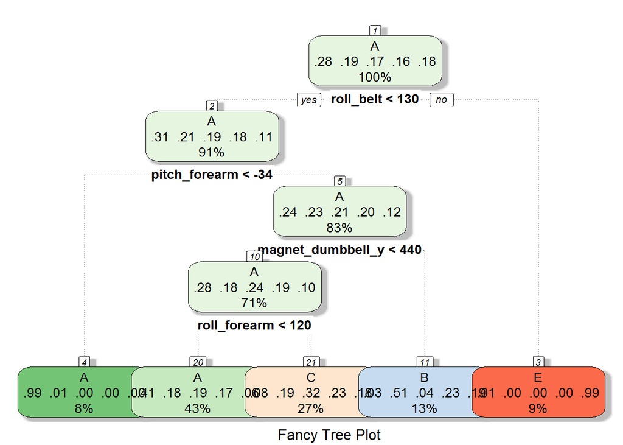

```r
library(rattle)
fancyRpartPlot(modTrees$finalModel, tweak=1.2, sub='Fancy Tree Plot')
```

Predicting new values

```r
predTrees <- predict(modTrees,testing)
table(predTrees,testing$classe)
```

```
##
## predTrees    A    B    C    D    E
##         A 1510  463  462  427  179
##         B   27  389   36  163  141
##         C  132  287  528  374  299
##         D    0    0    0    0    0
##         E    5    0    0    0  463
```

We can see that the accuracy is pretty low at around (1510+389+528+463)/5885=49%, let’s use random forest instead. We add the argument trainControl(method = “cv”) in the train function to request the train funciton to do cross validation using the random forest method.

```r
modRF <- train(classe ~ .,method="rf",data=training,trControl = trainControl(method = "cv"))
modRF
```

```
## Random Forest
##
## 13737 samples
##    52 predictor
##     5 classes: 'A', 'B', 'C', 'D', 'E'
##
## No pre-processing
## Resampling: Cross-Validated (10 fold)
## Summary of sample sizes: 12361, 12364, 12363, 12364, 12364, 12364, ...
## Resampling results across tuning parameters:
##
##   mtry  Accuracy   Kappa      Accuracy SD  Kappa SD
##    2    0.9922124  0.9901482  0.002585739  0.003271641
##   27    0.9920660  0.9899640  0.002068145  0.002616049
##   52    0.9850787  0.9811236  0.004786984  0.006056780
##
## Accuracy was used to select the optimal model using  the largest value.
## The final value used for the model was mtry = 2.
```

Prediction on the testing dataset.

```r
predRF <- predict(modRF,testing)
table(predRF,testing$classe)
```

```
##
## predRF    A    B    C    D    E
##      A 1673    3    0    0    0
##      B    1 1136    7    0    0
##      C    0    0 1018    8    0
##      D    0    0    1  954    2
##      E    0    0    0    2 1080
```

We can see the that the accuracy for this testing dataset is (1673+1136+1018+954+1080)/5885=99.6%. So an estimate of the out of sample error rate is 1-99.6% = 0.4%, which is a very good result.

To conclude, we will choose the random forest model modRF to predict 20 different test cases.